# Processing large datasets with Apache Spark and Amazon SageMaker

**This notebook run on `Data Science 3.0 - Python 3` kernel on a `ml.t3.large` instance**.

Amazon SageMaker Processing Jobs are used to analyze data and evaluate machine learning models on Amazon SageMaker. With Processing, you can use a simplified, managed experience on SageMaker to run your data processing workloads, such as feature engineering, data validation, model evaluation, and model interpretation. You can also use the Amazon SageMaker Processing APIs during the experimentation phase and after the code is deployed in production to evaluate performance.

[figure not shown]

The preceding diagram shows how Amazon SageMaker spins up a Processing job. Amazon SageMaker takes your script, copies your data from Amazon Simple Storage Service (Amazon S3), and then pulls a processing container. The processing container image can either be an Amazon SageMaker built-in image or a custom image that you provide. The underlying infrastructure for a Processing job is fully managed by Amazon SageMaker. Cluster resources are provisioned for the duration of your job, and cleaned up when a job completes. The output of the Processing job is stored in the Amazon S3 bucket you specified.

## Our workflow for processing large amounts of data with SageMaker

We can divide our workflow into two steps:

1. Work with a small subset of the data with Spark running in local model in a SageMaker Studio Notebook.
2. Once we are able to work with the small subset of data we can provide the same code (as a Python script rather than a series of interactive steps) to SageMaker Processing which launched a Spark cluster, runs out code and terminates the cluster.

## In this notebook...

We will analyze the [Pushshift Reddit dataset](https://arxiv.org/pdf/2001.08435.pdf) to be used for the project and then we will run a SageMaker Processing Job to filter out the comments and submissions from subreddits of interest. The filtered data will be stored in your account's s3 bucket and it is this filtered data that you will be using for your project.

## Setup

We need an available Java installation to run pyspark. The easiest way to do this is to install JDK and set the proper paths using conda

```python
# Setup - Run only once per Kernel App
%conda install https://anaconda.org/conda-forge/openjdk/11.0.1/download/linux-64/openjdk-11.0.1-hacce0ff_1021.tar.bz2

# install PySpark
%pip install pyspark==3.4.0

# restart kernel
from IPython.core.display import HTML
HTML("<script>Jupyter.notebook.kernel.restart()</script>")
```

```
Downloading and Extracting Packages:


## Package Plan ##

  environment location: /opt/conda



Preparing transaction: done
Verifying transaction: done
Executing transaction: done
```

## Utilize S3 Data within local PySpark

- By specifying the `hadoop-aws` jar in our Spark config we're able to access S3 datasets using the s3a file prefix.
- Since we've already authenticated ourself to SageMaker Studio , we can use our assumed SageMaker ExecutionRole for any S3 reads/writes by setting the credential provider as `ContainerCredentialsProvider`

```python
# Import pyspark and build Spark session
from pyspark.sql import SparkSession

spark = (
    SparkSession.builder.appName("PySparkApp")
    .config("spark.jars.packages", "org.apache.hadoop:hadoop-aws:3.2.2")
    .config(
        "fs.s3a.aws.credentials.provider",
        "com.amazonaws.auth.ContainerCredentialsProvider",
    )
    .getOrCreate()
)

print(spark.version)
```

```
:: loading settings :: url = jar:file:/opt/conda/lib/python3.11/site-packages/pyspark/jars/ivy-2.5.1.jar!/org/apache/ivy/core/settings/ivysettings.xml
```

[output not shown]

```
3.4.0
```

### Reading data into a Spark Dataframe

Note that we will be using the "s3a" adapter (read more [here](https://aws.amazon.com/blogs/opensource/community-collaboration-the-s3a-story)). S3A enables Hadoop to directly read and write Amazon S3 objects.

```python
%%time
comments = spark.read.parquet(
    "s3a://bigdatateaching/reddit-project/reddit/parquet/comments/yyyy=*/mm=*/*comments*.parquet",
    header=True
)
comments.show()
```

[output not shown]

[output not shown]

```python
%%time
submissions = spark.read.parquet(
    "s3a://bigdatateaching/reddit-project/reddit/parquet/submissions/yyyy=*/mm=*/*submissions*.parquet",
    header=True
)
submissions.show()
```

```
[Stage 5:>                                                          (0 + 1) / 1]
```

```
+--------------------+----------------------+-----------------+-----------+-------------+--------------------+------+-------+-------+------+------------+-------+----------+------------+-----+--------------------+--------+--------------------+------------+--------------------+--------------------+
|              author|author_flair_css_class|author_flair_text|created_utc|distinguished|              domain|edited|     id|is_self|locked|num_comments|over_18|quarantine|retrieved_on|score|            selftext|stickied|           subreddit|subreddit_id|               title|                 url|
+--------------------+----------------------+-----------------+-----------+-------------+--------------------+------+-------+-------+------+------------+-------+----------+------------+-----+--------------------+--------+--------------------+------------+--------------------+--------------------+
|     Newleaftherapy2|                  null|             null| 1689068092|         null|self.Newleaftherapy2|  null|14wmex5|   true| false|           0|  false|     false|  1689068113|    1| \n\nFind relief ...|   false|   u_Newleaftherapy2|   t5_8l1kf2|Discover CBT for ...|https://www.reddi...|
|         wcooper1298|                  null|             null| 1689068092|         null|           i.redd.it|  null|14wmex6|  false| false|           0|   true|     false|  1689068113|    1|                    |   false|   GaySnapchatImages|    t5_2xdxr|21 straight dude....|https://i.redd.it...|
|     Kattie_Meluanie|              Verified|         Verified| 1689068093|         null|           i.redd.it|  null|14wmex7|  false| false|           0|   true|     false|  1689068113|    1|                    |   false|              mombod|    t5_3ottt|I never get tired...|https://i.redd.it...|
|     sequence_string|                  null|             null| 1689068093|         null|           i.redd.it|  null|14wmex8|  false| false|           0|  false|     false|  1689068113|    1|                    |   false|           wallpaper|    t5_2qmjl|A Quiet Moment Be...|https://i.redd.it...|
|      mmmttisngksnsh|                  null|             null| 1689068093|         null|           i.redd.it|  null|14wmex9|  false| false|           0|  false|     false|  1689068113|    1|                    |   false|             firefly|    t5_2qs24|Does anyone need ...|https://i.redd.it...|
|       antoniipotkon|                  null|             null| 1689068093|         null|           i.redd.it|  null|14wmexa|  false| false|           4|   true|     false|  1689068113|    1|                    |   false|     Pickonepornstar|    t5_3kfxz|Create your own H...|https://i.redd.it...|
|        KinkyKorra27|                  null|  Unverified User| 1689068093|         null|           i.redd.it|  null|14wmexb|  false| false|           0|   true|     false|  1689068113|    1|                    |   false|     FullBackPanties|    t5_3i6no|My panties match ...|https://i.redd.it...|
|PassageIntelligent55|                  null|             null| 1689068093|         null|self.SpringfieldM...|  null|14wmexc|   true| false|           0|   true|     false|  1689068113|    1|                    |   false|SpringfieldMO_Hoo...|   t5_88dztd|(F4M)😍😍 I'm dow...|https://www.reddi...|
|           igorski81|                  null|             null| 1689068093|         null|drosophelia.bandc...|  null|14wmexd|  false| false|           1|  false|     false|  1689068113|    1|                    |   false|            BandCamp|    t5_2swys|4 Track "Industri...|https://drosophel...|
|SuperbAmbassador3086|                  null|             null| 1689068093|         null|self.Sissy_humili...|  null|14wmexe|   true| false|           0|   true|     false|  1689068113|    1|                    |   false|   Sissy_humiliation|    t5_2tnuq|25 (F4M) No roomm...|https://www.reddi...|
|  Content-Aside-3378|                  null|             null| 1689068093|         null|self.couplessexpi...|  null|14wmexf|   true| false|           0|   true|     false|  1689068113|    1|                    |   false|   couplessexpicswap|   t5_46jvuk|Trading my 21 yo ...|https://www.reddi...|
|   Excellent_Ear_951|                  null|             null| 1689068093|         null|         i.imgur.com|  null|14wmexg|  false| false|           0|   true|     false|  1689068113|    1|                    |   false| u_Excellent_Ear_951|   t5_4gvpsa|   Fully in comments|https://i.imgur.c...|
|         WhoAmIEven2|                  null|             null| 1689068093|         null|           i.redd.it|  null|14wmexh|  false| false|           0|  false|     false|  1689068113|    1|                    |   false|              gaming|    t5_2qh03|Left was made in ...|https://i.redd.it...|
|  Correct-Prompt6887|                  null|             null| 1689068093|         null|          self.KGBTR|  null|14wmexi|   true| false|           1|  false|     false|  1689068113|    1|Beyler telegram i...|   false|               KGBTR|   t5_12t6sw|Beyler telegram i...|https://www.reddi...|
|           3188steve|                  null|             null| 1689068093|         null|self.DickPicReque...|  null|14wmexj|   true|  true|           0|   true|     false|  1689068113|    1|              Age 55|   false|    DickPicRequestv2|   t5_7x4wox|(Age 55) Requesti...|https://www.reddi...|
```

[output cut: 10 more lines]

```python
%%time
print(f"shape of the submissions dataframe is {submissions.count():,}x{len(submissions.columns)}")
```

```
[Stage 6:======================================================>(637 + 1) / 638]
```

```
shape of the submissions dataframe is 567,890,869x21
CPU times: user 57.4 ms, sys: 14 ms, total: 71.4 ms
Wall time: 31.9 s
```

```python
%%time
print(f"shape of the comments dataframe is {comments.count():,}x{len(comments.columns)}")
```

```
[Stage 9:====================================================>(3674 + 3) / 3677]
```

```
shape of the comments dataframe is 3,675,768,958x17
CPU times: user 229 ms, sys: 58.4 ms, total: 287 ms
Wall time: 2min 2s
```

## Exploratory data analysis

```python
submissions.createOrReplaceTempView("submissions")
comments.createOrReplaceTempView("comments")
```

```python
%%time

sql_str="select subreddit, count(id) as count from submissions group by subreddit order by count desc"
submissions_subreddit_count = spark.sql(sql_str)
submissions_subreddit_count.show()
```

```
[Stage 14:================================================>       (19 + 3) / 22]
```

```
+--------------------+-------+
|           subreddit|  count|
+--------------------+-------+
|            dirtyr4r|3633005|
|         JerkOffChat|3616759|
|           AskReddit|2686082|
|   GaySnapchatImages|2655639|
|    GaySnapchatShare|2641484|
|       DirtySnapchat|1986200|
|      PokemonGoRaids|1341799|
|     slutsofsnapchat|1334782|
|PersonalizedGameRecs|1325223|
|  HentaiAndRoleplayy|1315212|
|   u_GrownBrilliance|1310625|
|   MonopolyGoTrading|1234245|
| relationship_advice|1149649|
|         MassiveCock|1096306|
|       DirtyChatPals|1024807|
|         Monopoly_GO| 970421|
|       AutoNewspaper| 946314|
|              GOONED| 917121|
|          ratemycock| 898375|
|    DickPicRequestv2| 863552|
+--------------------+-------+
only showing top 20 rows

CPU times: user 198 ms, sys: 40.1 ms, total: 238 ms
Wall time: 1min 46s
```

## Process S3 data with SageMaker Processing Job `PySparkProcessor`

We are going to move the above processing code in a Python file and then submit that file to SageMaker Processing Job's [`PySparkProcessor`](https://sagemaker.readthedocs.io/en/stable/amazon_sagemaker_processing.html#pysparkprocessor).

```python
!mkdir -p ./code
```

```python
%%writefile ./code/process.py

import os
import logging
import argparse

# Import pyspark and build Spark session
from pyspark.sql.functions import *
from pyspark.sql.types import (
    DoubleType,
    IntegerType,
    StringType,
    StructField,
    StructType,
)
from pyspark.sql import SparkSession
from pyspark.sql.functions import col

logging.basicConfig(format='%(asctime)s,%(levelname)s,%(module)s,%(filename)s,%(lineno)d,%(message)s', level=logging.DEBUG)
logger = logging.getLogger()
logger.setLevel(logging.DEBUG)
logger.addHandler(logging.StreamHandler(sys.stdout))

def main():
    parser = argparse.ArgumentParser(description="app inputs and outputs")
    parser.add_argument("--s3_dataset_path_commments", type=str, help="Path of dataset in S3 for reddit comments")
    parser.add_argument("--s3_dataset_path_submissions", type=str, help="Path of dataset in S3 for reddit submissions")
    parser.add_argument("--s3_output_bucket", type=str, help="s3 output bucket")
    parser.add_argument("--s3_output_prefix", type=str, help="s3 output prefix")
    parser.add_argument("--subreddits", type=str, help="comma separate list of subreddits of interest")
    args = parser.parse_args()

    spark = SparkSession.builder.appName("PySparkApp").getOrCreate()
    logger.info(f"spark version = {spark.version}")

    # This is needed to save RDDs which is the only way to write nested Dataframes into CSV format
    sc = spark.sparkContext
    sc._jsc.hadoopConfiguration().set(
        "mapred.output.committer.class", "org.apache.hadoop.mapred.FileOutputCommitter"
    )


    # Downloading the data from S3 into a Dataframe
    logger.info(f"going to read {args.s3_dataset_path_commments}")
    comments = spark.read.parquet(args.s3_dataset_path_commments, header=True)
    logger.info(f"finished reading files...")

    logger.info(f"going to read {args.s3_dataset_path_submissions}")
    submissions = spark.read.parquet(args.s3_dataset_path_submissions, header=True)
    logger.info(f"finished reading files...")

    # filter the dataframe to only keep the subreddits of interest
    subreddits = [s.strip() for s in args.subreddits.split(",")]
    excluded_cols = [] # ['edited', 'created_utc', 'retrieved_on']

    comments_included_cols = [c for c in comments.columns if c not in excluded_cols]
    logger.info(f"comments included_cols={comments_included_cols}")

    submissions_included_cols = [c for c in submissions.columns if c not in excluded_cols]
    logger.info(f"submissions included_cols={submissions_included_cols}")

    # subset the dataframes because "edited" and "created_utc" have data type problems
    # sometimes they occur as int some time as float and since schema is encoded in the
    # parquet files therefore different files have different data tpyes for these fields (float in some cases, int in some cases)
    # and spark enforces strict type checking on read so the only option we have is to either
    # fix this outside of spark or delete these columns.
    comments = comments.select(comments_included_cols)
    submissions = submissions.select(submissions_included_cols)

    submissions_filtered = submissions.where(lower(col("subreddit")).isin(subreddits))
    comments_filtered = comments.where(lower(col("subreddit")).isin(subreddits))

    # save the filtered dataframes so that these files can now be used for future analysis
    s3_path = f"s3://{args.s3_output_bucket}/{args.s3_output_prefix}/comments"
    logger.info(f"going to write comments for {subreddits} in {s3_path}")
    logger.info(f"shape of the comments_filtered dataframe is {comments_filtered.count():,}x{len(comments_filtered.columns)}")
    comments_filtered.write.mode("overwrite").parquet(s3_path)

    s3_path = f"s3://{args.s3_output_bucket}/{args.s3_output_prefix}/submissions"
    logger.info(f"going to write submissions for {subreddits} in {s3_path}")
    logger.info(f"shape of the submissions_filtered dataframe is {submissions_filtered.count():,}x{len(submissions_filtered.columns)}")
    submissions_filtered.write.mode("overwrite").parquet(s3_path)

if __name__ == "__main__":
    main()
```

```
Overwriting ./code/process.py
```

Now submit this code to SageMaker Processing Job.

```python
%%time
import sagemaker
from sagemaker.spark.processing import PySparkProcessor

# Setup the PySpark processor to run the job. Note the instance type and instance count parameters. SageMaker will create these many instances of this type for the spark job.
role = sagemaker.get_execution_role()
spark_processor = PySparkProcessor(
    base_job_name="sm-spark-project",
    framework_version="3.3",
    role=role,
    instance_count=4,
    instance_type="ml.m5.xlarge",
    max_runtime_in_seconds=3600,
)

# s3 paths
session = sagemaker.Session()
bucket = session.default_bucket()
s3_dataset_path_commments = "s3://bigdatateaching/reddit-project/reddit/parquet/comments/yyyy=*/mm=*/*.parquet"
s3_dataset_path_submissions = "s3://bigdatateaching/reddit-project/reddit/parquet/submissions/yyyy=*/mm=*/*.parquet"
output_prefix_data = "project"
output_prefix_logs = f"spark_logs"

# modify this comma separated list to choose the subreddits of interest
#subreddits = "technology,chatgpt"
subreddits = "investing,cryptocurrency"

# run the job now, the arguments array is provided as command line to the Python script (Spark code in this case).
spark_processor.run(
    submit_app="./code/process.py",
    arguments=[
        "--s3_dataset_path_commments",
        s3_dataset_path_commments,
        "--s3_dataset_path_submissions",
        s3_dataset_path_submissions,
        "--s3_output_bucket",
        bucket,
        "--s3_output_prefix",
        output_prefix_data,
        "--subreddits",
        subreddits,
    ],
    spark_event_logs_s3_uri="s3://{}/{}/spark_event_logs".format(bucket, output_prefix_logs),
    logs=False,
)
```

```
sagemaker.config INFO - Not applying SDK defaults from location: /etc/xdg/sagemaker/config.yaml
sagemaker.config INFO - Not applying SDK defaults from location: /home/sagemaker-user/.config/sagemaker/config.yaml
............................................................................................................................................................................................................................................................................................................…
Wall time: 40min 12s
```

## Read the filtered data

Now that we have filtered the data to only keep submissions and comments from subreddits of interest. Let us read data from the s3 path where we saved the filtered data.

```python
%%time
import sagemaker
from sagemaker.spark.processing import PySparkProcessor

# Setup the PySpark processor to run the job. Note the instance type and instance count parameters. SageMaker will create these many instances of this type for the spark job.
role = sagemaker.get_execution_role()
spark_processor = PySparkProcessor(
    base_job_name="sm-spark-project",
    framework_version="3.3",
    role=role,
    instance_count=4,
    instance_type="ml.m5.xlarge",
    max_runtime_in_seconds=3600,
)

# s3 paths
session = sagemaker.Session()
bucket = session.default_bucket()
s3_dataset_path_commments = "s3://bigdatateaching/reddit-project/reddit/parquet/comments/yyyy=*/mm=*/*.parquet"
s3_dataset_path_submissions = "s3://bigdatateaching/reddit-project/reddit/parquet/submissions/yyyy=*/mm=*/*.parquet"
output_prefix_data = "project"
output_prefix_logs = f"spark_logs"

# modify this comma separated list to choose the subreddits of interest
#subreddits = "technology,chatgpt"
subreddits = "investing,cryptocurrency"
```

```
sagemaker.config INFO - Not applying SDK defaults from location: /etc/xdg/sagemaker/config.yaml
sagemaker.config INFO - Not applying SDK defaults from location: /home/sagemaker-user/.config/sagemaker/config.yaml
sagemaker.config INFO - Not applying SDK defaults from location: /home/sagemaker-user/.config/sagemaker/config.yaml
CPU times: user 3.05 s, sys: 247 ms, total: 3.3 s
Wall time: 3.63 s
```

```python
%%time
s3_path = f"s3a://{bucket}/{output_prefix_data}/comments"
print(f"reading submissions from {s3_path}")
comments = spark.read.parquet(s3_path, header=True)
print(f"shape of the comments dataframe is {comments.count():,}x{len(comments.columns)}")
```

```
reading submissions from s3a://sagemaker-us-east-1-585282974528/project/comments
```

```
24/11/13 22:06:21 WARN MetricsConfig: Cannot locate configuration: tried hadoop-metrics2-s3a-file-system.properties,hadoop-metrics2.properties
[Stage 1:======================================================>(116 + 1) / 117]
```

```
shape of the comments dataframe is 3,877,393x17
CPU times: user 158 ms, sys: 19.9 ms, total: 178 ms
Wall time: 9min 27s
```

```python
comments.printSchema()
```

```
root
 |-- author: string (nullable = true)
 |-- author_flair_css_class: string (nullable = true)
 |-- author_flair_text: string (nullable = true)
 |-- body: string (nullable = true)
 |-- controversiality: long (nullable = true)
 |-- created_utc: long (nullable = true)
 |-- distinguished: string (nullable = true)
 |-- edited: double (nullable = true)
 |-- gilded: long (nullable = true)
 |-- id: string (nullable = true)
 |-- link_id: string (nullable = true)
 |-- parent_id: string (nullable = true)
 |-- retrieved_on: long (nullable = true)
 |-- score: long (nullable = true)
 |-- stickied: boolean (nullable = true)
 |-- subreddit: string (nullable = true)
 |-- subreddit_id: string (nullable = true)
```

```python
# display a subset of columns
comments.select("subreddit", "author", "body", "parent_id", "link_id", "id", "created_utc").show()
```

```
[Stage 4:>                                                          (0 + 1) / 1]
```

```
+--------------+--------------------+--------------------+----------+----------+-------+-----------+
|     subreddit|              author|                body| parent_id|   link_id|     id|created_utc|
+--------------+--------------------+--------------------+----------+----------+-------+-----------+
|CryptoCurrency|       TexasBoyz-713|Dude I wouldn’t s...|t1_jsjxgdf|t3_153et67|jsjxjpu| 1689744125|
|CryptoCurrency|         bthemonarch|Moons are the rea...|t1_jsjxcqm|t3_153et67|jsjxjuv| 1689744128|
|CryptoCurrency|        keithwee0909|Should I buy some...|t1_jsjxfk8|t3_153et67|jsjxk0f| 1689744130|
|CryptoCurrency|           [deleted]|           [removed]|t3_153et67|t3_153et67|jsjxk5v| 1689744133|
|CryptoCurrency|       Traveler-0854|¢0.63\n\nWe are o...|t3_153et67|t3_153et67|jsjxk5x| 1689744133|
|CryptoCurrency|       Illicitterror|    Prime Trustusbro|t3_153axby|t3_153axby|jsjxk66| 1689744133|
|CryptoCurrency|              vip887|Yup, a tiny mista...|t3_153ky0e|t3_153ky0e|jsjxk85| 1689744134|
|CryptoCurrency|         chintokkong|New Yorkers will ...|t3_153et67|t3_153et67|jsjxkfo| 1689744137|
|CryptoCurrency|       AutoModerator|\nHere is a [Nitt...|t1_jsjxkfo|t3_153et67|jsjxkgp| 1689744138|
|CryptoCurrency|           ziggyzago|I’m having crazy ...|t3_153et67|t3_153et67|jsjxkk4| 1689744140|
|CryptoCurrency|                R4ID|with how fast it ...|t3_153lm7j|t3_153lm7j|jsjxkkr| 1689744140|
|CryptoCurrency|           RedBunery|> Cathie Wood ass...|t3_153ip93|t3_153ip93|jsjxks6| 1689744143|
|CryptoCurrency|            ccModBot|Hello!\n\nDirect ...|t3_153lm7j|t3_153lm7j|jsjxl1m| 1689744148|
|CryptoCurrency|CoolCoolPapaOldSkool|Yellow for me for...|t3_153lm7j|t3_153lm7j|jsjxl24| 1689744148|
|CryptoCurrency|       Agile_Ad_7061|No. Prince from N...|t3_153ky0e|t3_153ky0e|jsjxl4z| 1689744150|
|CryptoCurrency|           Frogmangy|Literally know a ...|t1_jsjvuyx|t3_153ky0e|jsjxl5i| 1689744150|
|CryptoCurrency|  ImNotFromThisWorld|Man I should have...|t3_153et67|t3_153et67|jsjxlx6| 1689744163|
|CryptoCurrency|          send_tacoz|Aren't Doge price...|t3_153krw1|t3_153krw1|jsjxmgi| 1689744172|
|CryptoCurrency|      OddIndication4|Ask yourself the ...|t3_1539jks|t3_1539jks|jsjxmh7| 1689744172|
|CryptoCurrency|             chili21|           !gas nova|t3_12pf9pb|t3_12pf9pb|jsjxmpc| 1689744176|
+--------------+--------------------+--------------------+----------+----------+-------+-----------+
only showing top 20 rows
```

```python
%%time
s3_path = f"s3a://{bucket}/{output_prefix_data}/submissions"
print(f"reading submissions from {s3_path}")
submissions = spark.read.parquet(s3_path, header=True)
print(f"shape of the submissions dataframe is {submissions.count():,}x{len(submissions.columns)}")
```

```
reading submissions from s3a://sagemaker-us-east-1-585282974528/project/submissions
```

```
[Stage 5:=====================================================>   (17 + 1) / 18]
```

```
shape of the submissions dataframe is 205,720x21
CPU times: user 24.5 ms, sys: 4.8 ms, total: 29.3 ms
Wall time: 1min 27s
```

```python
submissions.printSchema()
```

```
root
 |-- author: string (nullable = true)
 |-- author_flair_css_class: string (nullable = true)
 |-- author_flair_text: string (nullable = true)
 |-- created_utc: long (nullable = true)
 |-- distinguished: string (nullable = true)
 |-- domain: string (nullable = true)
 |-- edited: double (nullable = true)
 |-- id: string (nullable = true)
 |-- is_self: boolean (nullable = true)
 |-- locked: boolean (nullable = true)
 |-- num_comments: long (nullable = true)
 |-- over_18: boolean (nullable = true)
 |-- quarantine: boolean (nullable = true)
 |-- retrieved_on: long (nullable = true)
 |-- score: long (nullable = true)
 |-- selftext: string (nullable = true)
 |-- stickied: boolean (nullable = true)
 |-- subreddit: string (nullable = true)
 |-- subreddit_id: string (nullable = true)
 |-- title: string (nullable = true)
 |-- url: string (nullable = true)
```

```python
# display a subset of columns
submissions.select("subreddit", "author", "title", "selftext", "num_comments", "created_utc").show()
```

```
+--------------+-------------------+--------------------+--------------------+------------+-----------+
|     subreddit|             author|               title|            selftext|num_comments|created_utc|
+--------------+-------------------+--------------------+--------------------+------------+-----------+
|     investing|       WichitaFlyer|Will negative pop...|Millennial and ge...|           0| 1689714390|
|CryptoCurrency|            V11c7or|            AITrader|           [removed]|           0| 1689714454|
|     investing| Ok_Supermarket9812|Tools to assess f...|           [removed]|           1| 1689714522|
|CryptoCurrency|    charlythesecond|Terraform Labs Co...|                    |           0| 1689714532|
|CryptoCurrency|    badfishbeefcake|Scam Alert: Celsi...|           [removed]|           2| 1689714536|
|CryptoCurrency|   Fun-Juggernautyy|Opinions on Hatom...|           [removed]|           1| 1689714660|
|CryptoCurrency|   Fun-Juggernautyy|Opinions on Hatom...|           [removed]|           1| 1689714664|
|CryptoCurrency|     OneThatNoseOne|Today, many peopl...|Safe to say that ...|           0| 1689714869|
|     investing| Ok_Supermarket9812|Tool to assess fu...|I am looking for ...|           0| 1689714939|
|CryptoCurrency|          [deleted]|SUI, its hype and...|           [removed]|           1| 1689715044|
|CryptoCurrency|         garchmodel|if arkham was rea...|           [removed]|           1| 1689715090|
|CryptoCurrency|    Fun_Problem_914|hola mrbeast no m...|           [removed]|           1| 1689715093|
|CryptoCurrency|          syndoms18|SUI, its hype and...|           [removed]|           1| 1689715103|
|CryptoCurrency|        RassuEst112|Are There Any Non...|           [removed]|           1| 1689715260|
|     investing|            StophJS|Your ETF portfoli...|This may be flagg...|           0| 1689715325|
|CryptoCurrency|   DrHunterThompson| MOONS Mass Adoption|           [removed]|           1| 1689715452|
|CryptoCurrency|           bdiggles|Where can U.S. tr...|           [removed]|           1| 1689715500|
|CryptoCurrency|        Oneiros1999|Prime Trust Put I...|                    |           0| 1689715584|
|CryptoCurrency|Artorias_the_hollow|I bought some Moo...|           [removed]|           1| 1689715619|
|CryptoCurrency|  Nearby_Market3054|Bitcoin mining an...|           [removed]|           1| 1689715639|
+--------------+-------------------+--------------------+--------------------+------------+-----------+
only showing top 20 rows
```

```python
crypto =  submissions.filter(submissions.subreddit == "CryptoCurrency")
```

```python
crypto.select("subreddit", "author", "title", "num_comments", "created_utc").show()
```

```
+--------------+-------------------+--------------------+------------+-----------+
|     subreddit|             author|               title|num_comments|created_utc|
+--------------+-------------------+--------------------+------------+-----------+
|CryptoCurrency|            V11c7or|            AITrader|           0| 1689714454|
|CryptoCurrency|    charlythesecond|Terraform Labs Co...|           0| 1689714532|
|CryptoCurrency|    badfishbeefcake|Scam Alert: Celsi...|           2| 1689714536|
|CryptoCurrency|   Fun-Juggernautyy|Opinions on Hatom...|           1| 1689714660|
|CryptoCurrency|   Fun-Juggernautyy|Opinions on Hatom...|           1| 1689714664|
|CryptoCurrency|     OneThatNoseOne|Today, many peopl...|           0| 1689714869|
|CryptoCurrency|          [deleted]|SUI, its hype and...|           1| 1689715044|
|CryptoCurrency|         garchmodel|if arkham was rea...|           1| 1689715090|
|CryptoCurrency|    Fun_Problem_914|hola mrbeast no m...|           1| 1689715093|
|CryptoCurrency|          syndoms18|SUI, its hype and...|           1| 1689715103|
|CryptoCurrency|        RassuEst112|Are There Any Non...|           1| 1689715260|
|CryptoCurrency|   DrHunterThompson| MOONS Mass Adoption|           1| 1689715452|
|CryptoCurrency|           bdiggles|Where can U.S. tr...|           1| 1689715500|
|CryptoCurrency|        Oneiros1999|Prime Trust Put I...|           0| 1689715584|
|CryptoCurrency|Artorias_the_hollow|I bought some Moo...|           1| 1689715619|
|CryptoCurrency|  Nearby_Market3054|Bitcoin mining an...|           1| 1689715639|
|CryptoCurrency|              gs003|Money accidentall...|           1| 1689715838|
|CryptoCurrency|            iroh_80|Crypto Trading Dr...|           0| 1689715852|
|CryptoCurrency|         chandum009|Is trading view b...|           1| 1689715863|
|CryptoCurrency|         chandum009|Is trading view b...|           1| 1689715973|
+--------------+-------------------+--------------------+------------+-----------+
only showing top 20 rows
```

# EDA Goals/Questions

### Business goal 1

Determine which cryptocurrencies are most frequently mentioned on Reddit to gauge general interest and popularity.

### Business goal 2

Determine the most common topics surrounding topics on reddit.

### Business goal 3

Determine how cryptocurreny prices affect discussions on cryptocurrencies on reddit.

# Submissions data overview and quality check

```python
%%time
s3_path = f"s3a://{bucket}/{output_prefix_data}/submissions"
print(f"reading submissions from {s3_path}")
submissions = spark.read.parquet(s3_path, header=True)
print(f"shape of the submissions dataframe is {submissions.count():,}x{len(submissions.columns)}")
```

[output not shown]

```python
submissions.printSchema()
```

```
root
 |-- author: string (nullable = true)
 |-- author_flair_css_class: string (nullable = true)
 |-- author_flair_text: string (nullable = true)
 |-- created_utc: long (nullable = true)
 |-- distinguished: string (nullable = true)
 |-- domain: string (nullable = true)
 |-- edited: double (nullable = true)
 |-- id: string (nullable = true)
 |-- is_self: boolean (nullable = true)
 |-- locked: boolean (nullable = true)
 |-- num_comments: long (nullable = true)
 |-- over_18: boolean (nullable = true)
 |-- quarantine: boolean (nullable = true)
 |-- retrieved_on: long (nullable = true)
 |-- score: long (nullable = true)
 |-- selftext: string (nullable = true)
 |-- stickied: boolean (nullable = true)
 |-- subreddit: string (nullable = true)
 |-- subreddit_id: string (nullable = true)
 |-- title: string (nullable = true)
 |-- url: string (nullable = true)
```

```python
crypto =  submissions.filter(submissions.subreddit == "CryptoCurrency")
```

```python
crypto.show()
```

```
+-------------------+----------------------+--------------------+-----------+-------------+-------------------+------+-------+-------+------+------------+-------+----------+------------+-----+--------------------+--------+--------------+------------+--------------------+--------------------+
|             author|author_flair_css_class|   author_flair_text|created_utc|distinguished|             domain|edited|     id|is_self|locked|num_comments|over_18|quarantine|retrieved_on|score|            selftext|stickied|     subreddit|subreddit_id|               title|                 url|
+-------------------+----------------------+--------------------+-----------+-------------+-------------------+------+-------+-------+------+------------+-------+----------+------------+-----+--------------------+--------+--------------+------------+--------------------+--------------------+
|            V11c7or|                  null|                null| 1689714454|         null|self.CryptoCurrency|  null|153ag6j|   true| false|           0|  false|     false|  1689714476|    1|           [removed]|   false|CryptoCurrency|    t5_2wlj3|            AITrader|https://www.reddi...|
|    charlythesecond|      Warning-level2-2|                 Tin| 1689714532|         null|     cryptonews.com|  null|153aha5|  false| false|           0|  false|     false|  1689714560|    1|                    |   false|CryptoCurrency|    t5_2wlj3|Terraform Labs Co...|https://cryptonew...|
|    badfishbeefcake|                  null|                null| 1689714536|         null|          i.redd.it|  null|153ahbh|  false| false|           2|  false|     false|  1689714560|    1|           [removed]|   false|CryptoCurrency|    t5_2wlj3|Scam Alert: Celsi...|https://i.redd.it...|
|   Fun-Juggernautyy|                  null|                null| 1689714660|         null|self.CryptoCurrency|  null|153aj9f|   true| false|           1|  false|     false|  1689714683|    1|           [removed]|   false|CryptoCurrency|    t5_2wlj3|Opinions on Hatom...|https://www.reddi...|
|   Fun-Juggernautyy|                  null|                null| 1689714664|         null|self.CryptoCurrency|  null|153ajcr|   true| false|           1|  false|     false|  1689714682|    1|           [removed]|   false|CryptoCurrency|    t5_2wlj3|Opinions on Hatom...|https://www.reddi...|
|     OneThatNoseOne|                      |                    | 1689714869|         null|self.CryptoCurrency|  null|153amgy|   true| false|           0|  false|     false|  1689714894|    1|Safe to say that ...|   false|CryptoCurrency|    t5_2wlj3|Today, many peopl...|https://www.reddi...|
|          [deleted]|                  null|                null| 1689715044|         null|                   |  null|153ap4d|   true| false|           1|  false|     false|  1689715071|    1|           [removed]|   false|CryptoCurrency|    t5_2wlj3|SUI, its hype and...|                    |
|         garchmodel|      Warning-level2-2|Tin | QC: BTC 16 ...| 1689715090|         null|self.CryptoCurrency|  null|153apt8|   true| false|           1|  false|     false|  1689715117|    1|           [removed]|   false|CryptoCurrency|    t5_2wlj3|if arkham was rea...|https://www.reddi...|
|    Fun_Problem_914|                  null|                null| 1689715093|         null|self.CryptoCurrency|  null|153aput|   true| false|           1|  false|     false|  1689715119|    1|           [removed]|   false|CryptoCurrency|    t5_2wlj3|hola mrbeast no m...|https://www.reddi...|
|          syndoms18|      Warning-level2-2|                 Tin| 1689715103|         null|self.CryptoCurrency|  null|153apzr|   true| false|           1|  false|     false|  1689715134|    1|           [removed]|   false|CryptoCurrency|    t5_2wlj3|SUI, its hype and...|https://www.reddi...|
|        RassuEst112|                  null|                null| 1689715260|         null|self.CryptoCurrency|  null|153asdf|   true| false|           1|  false|     false|  1689715304|    1|           [removed]|   false|CryptoCurrency|    t5_2wlj3|Are There Any Non...|https://www.reddi...|
|   DrHunterThompson|                  null|                null| 1689715452|         null|self.CryptoCurrency|  null|153avai|   true| false|           1|  false|     false|  1689715480|    1|           [removed]|   false|CryptoCurrency|    t5_2wlj3| MOONS Mass Adoption|https://www.reddi...|
|           bdiggles|                  null|                null| 1689715500|         null|self.CryptoCurrency|  null|153avzt|   true| false|           1|  false|     false|  1689715522|    1|           [removed]|   false|CryptoCurrency|    t5_2wlj3|Where can U.S. tr...|https://www.reddi...|
```

[output cut: 9 more lines]

```python
from pyspark.sql.functions import col, when, count
from pyspark.sql.types import DoubleType, FloatType

null_counts = crypto.select([
    count(when(col(c).isNull() | (col(c).cast(DoubleType()).isNotNull() & isnan(col(c))), c)).alias(c)
    if crypto.schema[c].dataType in [DoubleType(), FloatType()]
    else count(when(col(c).isNull(), c)).alias(c)
    for c in crypto.columns
])

null_counts.show()
```

```
[Stage 32:====================================================>   (17 + 1) / 18]
```

```
+------+----------------------+-----------------+-----------+-------------+------+------+---+-------+------+------------+-------+----------+------------+-----+--------+--------+---------+------------+-----+---+
|author|author_flair_css_class|author_flair_text|created_utc|distinguished|domain|edited| id|is_self|locked|num_comments|over_18|quarantine|retrieved_on|score|selftext|stickied|subreddit|subreddit_id|title|url|
+------+----------------------+-----------------+-----------+-------------+------+------+---+-------+------+------------+-------+----------+------------+-----+--------+--------+---------+------------+-----+---+
|     0|                105463|           101974|          0|       162618|     0|162024|  0|      0|     0|           0|      0|         0|           0|    0|       0|       0|        0|           0|    0|  0|
+------+----------------------+-----------------+-----------+-------------+------+------+---+-------+------+------------+-------+----------+------------+-----+--------+--------+---------+------------+-----+---+
```

```python
from pyspark.sql.functions import length

shortest_titles = crypto.select("title") \
                        .withColumn("title_length", length("title")) \
                        .orderBy("title_length") \
                        .limit(20)

shortest_titles.show(truncate=False)
```

```
[Stage 40:====================================================>   (17 + 1) / 18]
```

```
+-----+------------+
|title|title_length|
+-----+------------+
|🌕   |1           |
|I    |1           |
|😓   |1           |
|P    |1           |
|D    |1           |
|B    |1           |
|C    |1           |
|💶   |1           |
|.    |1           |
|Z    |1           |
|🤠   |1           |
|S    |1           |
|C    |1           |
|F    |1           |
|.    |1           |
|🌞   |1           |
|0    |1           |
|😅   |1           |
|…    |1           |
|M    |1           |
+-----+------------+
```

# Comments data overview and quality check

```python
%%time
s3_path = f"s3a://{bucket}/{output_prefix_data}/comments"
print(f"reading submissions from {s3_path}")
comments = spark.read.parquet(s3_path, header=True)
print(f"shape of the comments dataframe is {comments.count():,}x{len(comments.columns)}")
```

[output not shown]

```python
comments.printSchema()
```

[output not shown]

```python
crypto_comments =  comments.filter(comments.subreddit == "CryptoCurrency")
```

```python
crypto_comments.show()
```

```
+--------------------+----------------------+--------------------+--------------------+----------------+-----------+-------------+------+------+-------+----------+----------+------------+-----+--------+--------------+------------+
|              author|author_flair_css_class|   author_flair_text|                body|controversiality|created_utc|distinguished|edited|gilded|     id|   link_id| parent_id|retrieved_on|score|stickied|     subreddit|subreddit_id|
+--------------------+----------------------+--------------------+--------------------+----------------+-----------+-------------+------+------+-------+----------+----------+------------+-----+--------+--------------+------------+
|       TexasBoyz-713|                      |Platinum | QC: BT...|Dude I wouldn’t s...|               0| 1689744125|         null|  null|     0|jsjxjpu|t3_153et67|t1_jsjxgdf|  1689744144|    1|   false|CryptoCurrency|    t5_2wlj3|
|         bthemonarch|             Developer|   FOMO chub for all|Moons are the rea...|               0| 1689744128|         null|  null|     0|jsjxjuv|t3_153et67|t1_jsjxcqm|  1689744159|    1|   false|CryptoCurrency|    t5_2wlj3|
|        keithwee0909|                  null|                null|Should I buy some...|               0| 1689744130|         null|  null|     0|jsjxk0f|t3_153et67|t1_jsjxfk8|  1689744159|    1|   false|CryptoCurrency|    t5_2wlj3|
|           [deleted]|                  null|                null|           [removed]|               0| 1689744133|         null|  null|     0|jsjxk5v|t3_153et67|t3_153et67|  1689744159|    1|   false|CryptoCurrency|    t5_2wlj3|
|       Traveler-0854|                  null|                null|¢0.63\n\nWe are o...|               0| 1689744133|         null|  null|     0|jsjxk5x|t3_153et67|t3_153et67|  1689744159|    1|   false|CryptoCurrency|    t5_2wlj3|
|       Illicitterror|                  null|                null|    Prime Trustusbro|               0| 1689744133|         null|  null|     0|jsjxk66|t3_153axby|t3_153axby|  1689744159|    1|   false|CryptoCurrency|    t5_2wlj3|
|              vip887|      Warning-level2-2|                 Tin|Yup, a tiny mista...|               0| 1689744134|         null|  null|     0|jsjxk85|t3_153ky0e|t3_153ky0e|  1689744159|    1|   false|CryptoCurrency|    t5_2wlj3|
|         chintokkong|                      |Platinum | QC: CC 33|New Yorkers will ...|               0| 1689744137|         null|  null|     0|jsjxkfo|t3_153et67|t3_153et67|  1689744161|    1|   false|CryptoCurrency|    t5_2wlj3|
|       AutoModerator|                  null|                null|\nHere is a [Nitt...|               0| 1689744138|    moderator|  null|     0|jsjxkgp|t3_153et67|t1_jsjxkfo|  1689744161|    1|   false|CryptoCurrency|    t5_2wlj3|
|           ziggyzago|                      |Platinum | QC: CC...|I’m having crazy ...|               0| 1689744140|         null|  null|     0|jsjxkk4|t3_153et67|t3_153et67|  1689744161|    1|   false|CryptoCurrency|    t5_2wlj3|
|                R4ID|                      |Platinum | QC: CC...|with how fast it ...|               0| 1689744140|         null|  null|     0|jsjxkkr|t3_153lm7j|t3_153lm7j|  1689744161|    1|   false|CryptoCurrency|    t5_2wlj3|
|           RedBunery|                  null|                null|> Cathie Wood ass...|               0| 1689744143|         null|  null|     0|jsjxks6|t3_153ip93|t3_153ip93|  1689744170|    1|   false|CryptoCurrency|    t5_2wlj3|
|            ccModBot|                   bot|              CC Bot|Hello!\n\nDirect ...|               0| 1689744148|    moderator|  null|     0|jsjxl1m|t3_153lm7j|t3_153lm7j|  1689744170|    1|    true|CryptoCurrency|    t5_2wlj3|
|CoolCoolPapaOldSkool|                      |Platinum | QC: CC...|Yellow for me for...|               0| 1689744148|         null|  null|     0|jsjxl24|t3_153lm7j|t3_153lm7j|  1689744170|    1|   false|CryptoCurrency|    t5_2wlj3|
|       Agile_Ad_7061|                  null|                null|No. Prince from N...|               0| 1689744150|         null|  null|     0|jsjxl4z|t3_153ky0e|t3_153ky0e|  1689744170|    1|   false|CryptoCurrency|    t5_2wlj3|
|           Frogmangy|      Warning-level2-2|     Tin | CC critic|Literally know a ...|               0| 1689744150|         null|  null|     0|jsjxl5i|t3_153ky0e|t1_jsjvuyx|  1689744170|    1|   false|CryptoCurrency|    t5_2wlj3|
|  ImNotFromThisWorld|      Warning-level2-2|                 Tin|Man I should have...|               0| 1689744163|         null|  null|     0|jsjxlx6|t3_153et67|t3_153et67|  1689744186|    1|   false|CryptoCurrency|    t5_2wlj3|
|          send_tacoz|                  null|                null|Aren't Doge price...|               0| 1689744172|         null|  null|     0|jsjxmgi|t3_153krw1|t3_153krw1|  1689744200|    1|   false|CryptoCurrency|    t5_2wlj3|
|      OddIndication4|      Warning-level2-2|                 Tin|Ask yourself the ...|               0| 1689744172|         null|  null|     0|jsjxmh7|t3_1539jks|t3_1539jks|  1689744200|    1|   false|CryptoCurrency|    t5_2wlj3|
|             chili21|      Warning-level2-2|                 Tin|           !gas nova|               0| 1689744176|         null|  null|     0|jsjxmpc|t3_12pf9pb|t3_12pf9pb|  1689744200|    1|   false|CryptoCurrency|    t5_2wlj3|
+--------------------+----------------------+--------------------+--------------------+----------------+-----------+-------------+------+------+-------+----------+----------+------------+-----+--------+--------------+------------+
only showing top 20 rows
```

```python
comments_null_counts = crypto_comments.select([
    count(when(col(c).isNull() | (col(c).cast(DoubleType()).isNotNull() & isnan(col(c))), c)).alias(c)
    if crypto_comments.schema[c].dataType in [DoubleType(), FloatType()]
    else count(when(col(c).isNull(), c)).alias(c)
    for c in crypto_comments.columns
])

comments_null_counts.show()
```

```
[Stage 37:=====================================================>(115 + 2) / 117]
```

```
+------+----------------------+-----------------+----+----------------+-----------+-------------+-------+------+---+-------+---------+------------+-----+--------+---------+------------+
|author|author_flair_css_class|author_flair_text|body|controversiality|created_utc|distinguished| edited|gilded| id|link_id|parent_id|retrieved_on|score|stickied|subreddit|subreddit_id|
+------+----------------------+-----------------+----+----------------+-----------+-------------+-------+------+---+-------+---------+------------+-----+--------+---------+------------+
|     0|               1052333|           931198|   0|               0|          0|      3276934|3337312|     0|  0|      0|        0|           0|    0|       0|        0|           0|
+------+----------------------+-----------------+----+----------------+-----------+-------------+-------+------+---+-------+---------+------------+-----+--------+---------+------------+
```

# EDA Questions Analysis

```python
from pyspark.sql.functions import explode, split, lower
from pyspark.ml.feature import StopWordsRemover

custom_stopwords = ["-", " ", "get", "need"]

stopwords = StopWordsRemover.loadDefaultStopWords("english")
all_stopwords = stopwords + custom_stopwords

words_array_df = crypto.select(split(lower(crypto.title), "\s+").alias("words_array"))

remover = StopWordsRemover(inputCol="words_array", outputCol="filtered_words_array", stopWords=all_stopwords)

filtered_array_df = remover.transform(words_array_df)

words_df = filtered_array_df.select(explode("filtered_words_array").alias("word"))
word_counts = words_df.groupBy("word").count().orderBy("count", ascending=False)
```

```python
word_counts.show(30)
```

```
[Stage 17:====================================================>   (17 + 1) / 18]
```

```
+--------------+-----+
|          word|count|
+--------------+-----+
|        crypto|27083|
|       bitcoin|14400|
|              | 6498|
|           new| 6412|
|       binance| 5032|
|        wallet| 3997|
|           btc| 3975|
|      exchange| 3700|
|       trading| 3691|
|         price| 3607|
|cryptocurrency| 3604|
|           sec| 3545|
|          coin| 3506|
|          best| 3455|
|        market| 3400|
|          help| 3314|
|           buy| 3196|
|      ethereum| 3189|
|         token| 3080|
|            us| 2963|
|      coinbase| 2934|
|    blockchain| 2622|
|           etf| 2600|
|           eth| 2376|
|         money| 2330|
|             || 2277|
|       million| 2250|
|         coins| 2163|
|          next| 2040|
|          says| 1975|
+--------------+-----+
only showing top 30 rows
```

```python
comments_words_array_df = crypto_comments.select(split(lower(crypto_comments.body), "\s+").alias("words_array"))

remover = StopWordsRemover(inputCol="words_array", outputCol="filtered_words_array", stopWords=all_stopwords)

comments_filtered_array_df = remover.transform(comments_words_array_df)

comments_words_df = comments_filtered_array_df.select(explode("filtered_words_array").alias("word"))
comments_word_counts = comments_words_df.groupBy("word").count().orderBy("count", ascending=False)
```

```python
comments_word_counts.show(30)
```

```
[Stage 22:>                                                         (0 + 2) / 2]
```

```
+---------+------+
|     word| count|
+---------+------+
|        >|433926|
|     like|301882|
|   crypto|253825|
|   people|220237|
|  bitcoin|204609|
|[removed]|192109|
|      one|171785|
|    think|153139|
|      btc|148812|
|     good|136576|
|     even|136389|
|     time|134354|
|    still|133193|
|    money|127486|
|    moons|126558|
|   please|126188|
|      see|123186|
|      new|119190|
|     make|116744|
|      buy|112002|
|    going|111563|
|     it’s|110569|
|     also|110084|
|     know|104195|
|   market|103583|
|     much|103402|
|     post|100119|
|      use| 97728|
|       go| 97510|
|      eth| 92805|
+---------+------+
only showing top 30 rows
```

```python
target_words = ["bitcoin", "ethereum", "tether", "binance", "usd", "solana", "xrp", "dogecoin", "tron", "polygon", "cardano", "chainlink"]

target_word_counts = word_counts.filter(word_counts.word.isin(target_words))

target_word_counts.show()
```

```
[Stage 29:====================================================>   (17 + 1) / 18]
```

```
+---------+-----+
|     word|count|
+---------+-----+
|  bitcoin|14400|
|  binance| 5032|
| ethereum| 3189|
|   solana| 1939|
|      xrp| 1584|
|  polygon|  687|
|  cardano|  660|
| dogecoin|  504|
|   tether|  467|
|      usd|  455|
|chainlink|  281|
|     tron|  188|
+---------+-----+
```

```python
comments_target_word_counts = comments_word_counts.filter(comments_word_counts.word.isin(target_words))

comments_target_word_counts.show()
```

```
[Stage 26:=====================================================>(116 + 1) / 117]
```

```
+---------+------+
|     word| count|
+---------+------+
|  bitcoin|204609|
| ethereum| 45088|
|  binance| 35341|
|      xrp| 19090|
|   solana| 18744|
|      usd| 11860|
|  cardano|  9644|
|   tether|  8459|
|  polygon|  8426|
|chainlink|  5125|
| dogecoin|  3711|
|     tron|  2653|
+---------+------+
```

```python
from pyspark.sql.functions import from_unixtime, min, max, date_format

crypto_time = crypto.withColumn("created_time", from_unixtime("created_utc", "yyyy-MM-dd HH:mm:ss"))
```

```python
crypto_time.select("subreddit", "author", "title", "score", "created_time").show()
```

```
+--------------+-------------------+--------------------+-----+-------------------+
|     subreddit|             author|               title|score|       created_time|
+--------------+-------------------+--------------------+-----+-------------------+
|CryptoCurrency|            V11c7or|            AITrader|    1|2023-07-18 21:07:34|
|CryptoCurrency|    charlythesecond|Terraform Labs Co...|    1|2023-07-18 21:08:52|
|CryptoCurrency|    badfishbeefcake|Scam Alert: Celsi...|    1|2023-07-18 21:08:56|
|CryptoCurrency|   Fun-Juggernautyy|Opinions on Hatom...|    1|2023-07-18 21:11:00|
|CryptoCurrency|   Fun-Juggernautyy|Opinions on Hatom...|    1|2023-07-18 21:11:04|
|CryptoCurrency|     OneThatNoseOne|Today, many peopl...|    1|2023-07-18 21:14:29|
|CryptoCurrency|          [deleted]|SUI, its hype and...|    1|2023-07-18 21:17:24|
|CryptoCurrency|         garchmodel|if arkham was rea...|    1|2023-07-18 21:18:10|
|CryptoCurrency|    Fun_Problem_914|hola mrbeast no m...|    1|2023-07-18 21:18:13|
|CryptoCurrency|          syndoms18|SUI, its hype and...|    1|2023-07-18 21:18:23|
|CryptoCurrency|        RassuEst112|Are There Any Non...|    1|2023-07-18 21:21:00|
|CryptoCurrency|   DrHunterThompson| MOONS Mass Adoption|    1|2023-07-18 21:24:12|
|CryptoCurrency|           bdiggles|Where can U.S. tr...|    1|2023-07-18 21:25:00|
|CryptoCurrency|        Oneiros1999|Prime Trust Put I...|    1|2023-07-18 21:26:24|
|CryptoCurrency|Artorias_the_hollow|I bought some Moo...|    1|2023-07-18 21:26:59|
|CryptoCurrency|  Nearby_Market3054|Bitcoin mining an...|    1|2023-07-18 21:27:19|
|CryptoCurrency|              gs003|Money accidentall...|    1|2023-07-18 21:30:38|
|CryptoCurrency|            iroh_80|Crypto Trading Dr...|    1|2023-07-18 21:30:52|
|CryptoCurrency|         chandum009|Is trading view b...|    1|2023-07-18 21:31:03|
|CryptoCurrency|         chandum009|Is trading view b...|    1|2023-07-18 21:32:53|
+--------------+-------------------+--------------------+-----+-------------------+
only showing top 20 rows
```

```python
date_range = crypto_time.select(
    min("created_time").alias("earliest_date"),
    max("created_time").alias("latest_date")
)

date_range.show()
```

```
[Stage 18:====================================================>   (17 + 1) / 18]
```

```
+-------------------+-------------------+
|      earliest_date|        latest_date|
+-------------------+-------------------+
|2023-06-01 00:00:06|2024-07-31 23:51:40|
+-------------------+-------------------+
```

```python
crypto_day = crypto_time.withColumn("date", date_format("created_time", "yyyy-MM-dd"))

posts_per_day = crypto_day.groupBy("date").count().orderBy("date")
```

```python
posts_per_day.show()
```

```
[Stage 21:====================================================>   (17 + 1) / 18]
```

```
+----------+-----+
|      date|count|
+----------+-----+
|2023-06-01|  505|
|2023-06-02|  435|
|2023-06-03|  399|
|2023-06-04|  410|
|2023-06-05|  539|
|2023-06-06|  679|
|2023-06-07|  538|
|2023-06-08|  522|
|2023-06-09|  612|
|2023-06-10|  507|
|2023-06-11|  435|
|2023-06-12|    2|
|2023-06-13|    1|
|2023-06-14|  645|
|2023-06-15|  558|
|2023-06-16|  475|
|2023-06-17|  372|
|2023-06-18|  355|
|2023-06-19|  453|
|2023-06-20|  433|
+----------+-----+
only showing top 20 rows
```

```python
crypto_comments =  comments.filter(comments.subreddit == "CryptoCurrency")
crypto_com_time = crypto_comments.withColumn("created_time", from_unixtime("created_utc", "yyyy-MM-dd HH:mm:ss"))
crypto_com_day = crypto_com_time.withColumn("date", date_format("created_time", "yyyy-MM-dd"))

comments_per_day = crypto_com_day.groupBy("date").count().orderBy("date")
```

```python
comments_per_day.show()
```

```
[Stage 24:=====================================================>(116 + 1) / 117]
```

```
+----------+-----+
|      date|count|
+----------+-----+
|2023-06-01|11345|
|2023-06-02|10361|
|2023-06-03| 8284|
|2023-06-04|10499|
|2023-06-05|12784|
|2023-06-06|14261|
|2023-06-07|13970|
|2023-06-08|12281|
|2023-06-09|13010|
|2023-06-10|16681|
|2023-06-11|10340|
|2023-06-12|   10|
|2023-06-13|    3|
|2023-06-14|14310|
|2023-06-15|12895|
|2023-06-16|11387|
|2023-06-17| 9463|
|2023-06-18| 9437|
|2023-06-19|10036|
|2023-06-20|11182|
+----------+-----+
only showing top 20 rows
```

```python
posts_per_day.count()
```

```
[Stage 8:=====================================================>   (17 + 1) / 18]
```

```
427
```

```python
comments_per_day_df = comments_per_day.toPandas()
```

```python
posts_per_day_df = posts_per_day.toPandas()
```

```python
import pandas as pd
```

```python
posts_per_day_df.head()
```

[output not shown]

```python
comments_per_day_df.head()
```

|  | date | count |
| --- | --- | --- |
| 0 | 2023-06-01 | 11345 |
| 1 | 2023-06-02 | 10361 |
| 2 | 2023-06-03 | 8284 |
| 3 | 2023-06-04 | 10499 |
| 4 | 2023-06-05 | 12784 |

```python
comments_per_day_df.rename(columns={'count': 'comments_count'}, inplace=True)
posts_per_day_df.rename(columns={'count': 'posts_count'}, inplace=True)
```

```python
comments_per_day_df.head()
```

|  | date | comments_count |
| --- | --- | --- |
| 0 | 2023-06-01 | 11345 |
| 1 | 2023-06-02 | 10361 |
| 2 | 2023-06-03 | 8284 |
| 3 | 2023-06-04 | 10499 |
| 4 | 2023-06-05 | 12784 |

```python
full_counts = comments_per_day_df.merge(posts_per_day_df, on = 'date')

full_counts.head()
```

|  | date | comments_count | posts_count |
| --- | --- | --- | --- |
| 0 | 2023-06-01 | 11345 | 505 |
| 1 | 2023-06-02 | 10361 | 435 |
| 2 | 2023-06-03 | 8284 | 399 |
| 3 | 2023-06-04 | 10499 | 410 |
| 4 | 2023-06-05 | 12784 | 539 |

data sources:

btc prices: https://github.com/Habrador/Bitcoin-price-visualization/blob/main/Bitcoin-price-USD.csv s&p index: https://www.spglobal.com/spdji/en/indices/digital-assets/sp-cryptocurrency-broad-digital-market-index/#overview

```python
btc = pandas.read_csv('Bitcoin-price-USD.csv')
sp = pandas.read_csv('PerformanceGraphExport.csv')
```

```python
print(sp.columns)
```

```
Index(['Effective date ',
       'S&P Cryptocurrency Broad Digital Market Index (USD)', 'Unnamed: 2',
       'Unnamed: 3', 'Unnamed: 4', 'Unnamed: 5', 'Unnamed: 6', 'Unnamed: 7',
       'Unnamed: 8', 'Unnamed: 9'],
      dtype='object')
```

```python
sp = sp[['Effective date ', 'S&P Cryptocurrency Broad Digital Market Index (USD)']]
```

```python
sp.rename(columns={'Effective date ': 'date'}, inplace=True)
sp.rename(columns={'S&P Cryptocurrency Broad Digital Market Index (USD)': 'S&P Crypto Index'}, inplace=True)
btc.rename(columns={'Date': 'date'}, inplace=True)
btc.rename(columns={'Price': 'btc_price'}, inplace=True)
```

```python
sp['date'] = pd.to_datetime(sp['date'], errors='coerce')
btc['date'] = pd.to_datetime(btc['date'], errors='coerce')
full_counts['date'] = pd.to_datetime(full_counts['date'], errors='coerce')
```

```python
print(btc.head())
print(sp.head())
```

```
        date  btc_price
0 2010-07-18       0.09
1 2010-07-19       0.08
2 2010-07-20       0.07
3 2010-07-21       0.08
4 2010-07-22       0.05
        date  S&P Crypto Index
0 2021-11-08           6111.93
1 2021-11-09           6215.99
2 2021-11-10           6031.64
3 2021-11-11           6057.05
4 2021-11-12           5988.32
```

```python
#sp['date'] = sp['date'].astype('object')
print(sp['date'].dtype)
print(btc['date'].dtype)
print(full_counts['date'].dtype)
```

```
datetime64[ns]
datetime64[ns]
datetime64[ns]
```

```python
counts_prices = pd.merge(full_counts, btc, on='date', how='inner')
counts_prices = pd.merge(counts_prices, sp, on='date', how='inner')
```

```python
counts_prices.head()
```

|  | date | comments_count | posts_count | btc_price | S&P Crypto Index |
| --- | --- | --- | --- | --- | --- |
| 0 | 2023-06-01 | 11345 | 505 | 26819.972656 | 2061.48 |
| 1 | 2023-06-02 | 10361 | 435 | 27249.589844 | 2095.26 |
| 2 | 2023-06-05 | 12784 | 539 | 25760.097656 | 1966.34 |
| 3 | 2023-06-06 | 14261 | 679 | 27238.783203 | 2062.70 |
| 4 | 2023-06-07 | 13970 | 538 | 26345.998047 | 2002.44 |

```python
pip install seaborn
```

```python
import seaborn as sns
import matplotlib.pyplot as plt
```

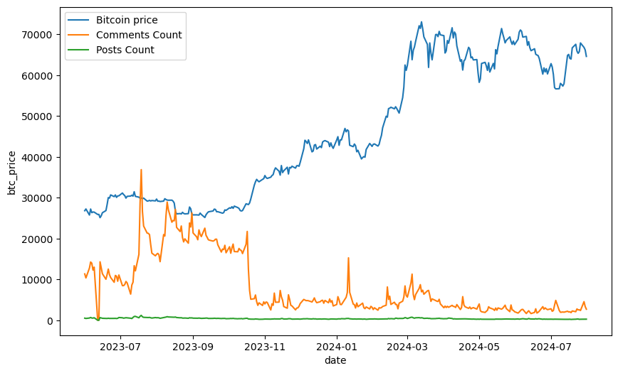

```python
plt.figure(figsize=(10, 6))

sns.lineplot(data=counts_prices, x='date', y='btc_price', label='Bitcoin price')


sns.lineplot(data=counts_prices, x='date', y='comments_count', label='Comments Count')
sns.lineplot(data=counts_prices, x='date', y='posts_count', label='Posts Count')
```

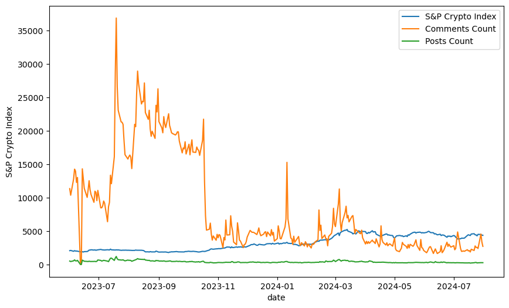

```python
plt.figure(figsize=(10, 6))


sns.lineplot(data=counts_prices, x='date', y='S&P Crypto Index', label='S&P Crypto Index')

sns.lineplot(data=counts_prices, x='date', y='comments_count', label='Comments Count')
sns.lineplot(data=counts_prices, x='date', y='posts_count', label='Posts Count')
```

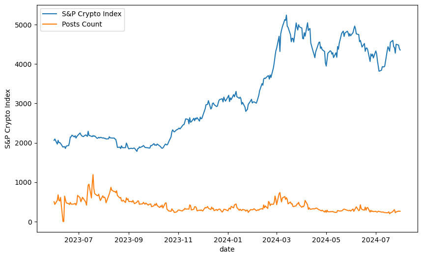

```python
plt.figure(figsize=(10, 6))

sns.lineplot(data=counts_prices, x='date', y='S&P Crypto Index', label='S&P Crypto Index')
sns.lineplot(data=counts_prices, x='date', y='posts_count', label='Posts Count')
```

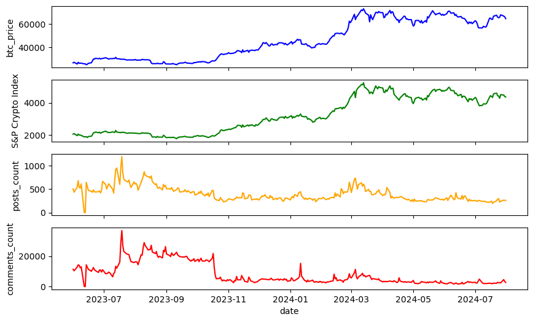

```python
fig, axs = plt.subplots(4, 1, figsize=(10, 6), sharex=True)

sns.lineplot(data=counts_prices, x='date', y='btc_price', ax=axs[0], color='blue')
sns.lineplot(data=counts_prices, x='date', y='S&P Crypto Index', ax=axs[1], color='green')
sns.lineplot(data=counts_prices, x='date', y='posts_count', ax=axs[2], color='orange')
sns.lineplot(data=counts_prices, x='date', y='comments_count', ax=axs[3], color='red')
```